# The problem with the Cournot Game

We found some issues with the physical (and econmic) reality of the basic formulation of the event driven Cournot game. They include:

1. When there is a demand shock, typically the quantity consumed changes because people buy less. Therefore the assumption that prices automatically adjust to keep consumption at a constant rate is not true. Or in other words, demand shocks yield inventory buildups.
2. The idea of a message being an infinitesimal rate of production is physi- cally awkward at best and physically impossible at worse.
3. Even under a constant demand regime, quantities in the market vary and that is a piece of information that firms use to set their quantity and price.

# Bertrand-like game

The goal of this version of market competition is to bring the Cournot model closer to reality.

###### The players

- The player's set a **price** by sending messages to the market.

###### The Market

- The market places "orders" from each of the firms by sending messages to the firm.
- The content of each message is an order quantity that is determined by the prices of both firms
- The rate at which the market sends messages to the firms is fixed
- The state of the market determines the demand function for each firm.

###### Profits

Player's earn profits every time thet receive an order. Profits are compute as their revenue minus an exogenous cost. We completely abstract away from prodction decisions, inventory buildup and production cost structure, though there is no reason this would have to hold in the future.

# Formalization

- For any internal state, the players can set a price in $[5, 10, 15, 20]$
- Players can only change their price upon receiving an order. That is, there are no spontaneous transmissions, only stimulated ones.
- The market's state is defined by a triple, $(s, p_1, p_2)$. $p_1$ and $p_2$ are the most recent prices the market has received from the players. $s$ can take one of 3 values, $[30, 50, 70]$ representing states of demand. The prices in the market determine the order quantity. More specifically, the order quantity received by player $i$ is given by $Q_i = s_m - p_i + .5p_j$ where $s_m$ is the state of the market. (Economically, these goods are substitutes, the coefficient on $p_j$ gives the degree of substitutability)
- The state of the market evolves stochastically according to an underlying Poisson process.
- The player's state consists of the most recent price they sent to the market as well as the price and order quantity of their last two messages received.

# Some Counting

# Shrinking the game

Now, let's just assume that the player's state is the most recent order it received. (That is, a price and quantity combo):

- Then the state space has size $4\times 4 \times 3=48$ and the players have $4^{48}$ total profiles.
- The total number of joiunt profiles is approx $4^{96}$ which is approx $10^{57}$. This might still be too big but let's give it a whirl.

### Imports

```julia
using PyCall
@pyimport adsy.display as ad
ad.extended_styles()
```

```julia
using StatsBase
using Distributions
using PyPlot
```

```
INFO: Loading help data...
```

### Message Type

```julia
# A Message Event in an SFT-Net
type Message
    sender::ASCIIString
    receiver::ASCIIString
    content::Any
    rate::Float64
end
```

### Spontaneous Event Type

```julia
type Spont
    sftname::ASCIIString
    rate::Float64
    newstate::Any # The state the node changes to
    messagesout::Array{Message, 1} # Messagges spontaneously emitted
end
```

### Player Type

```julia
## A Player in the Cournot Game
type Player
    discount::Float64 # Discount Rate
    messages::Array{Message, 1} # List of messages or message set!
    cost::Float64 # Per unit Cost

    ############################# ACTION NEEDS TO BE REDEFINED TO BE A STRATEGY! ###
    strategy::Dict{(Message, Any), (Message, Any)} # CHANGE THIS TO ANY ANY SINCE MESSAGES MIGHT BE AN ARRAY
    statespace::Array{Any, 1} # The state space
    currentstate::Any
    price_since_last_event::Float64
    name::ASCIIString
    trembling::Bool
    trembleprob::Float64
    ## Technically, quantitysincelastevent is a deterministic
    ## element of the state space given the messages.  Here it is used
    ## for accounting purposes.  Last event is last event in the game.
end


# In general, the set of available actions should depend on the state/message received.  However, in
# this game, the player is only going to change his state and send messages and this will not depend
# on his current state or the message he receives.  Therefore, the elements of 'action' are probably going
# to be tuples of the form (Message, State Transition).  Therefore, we can define actions as the cross product of
# messages and states;
```

### Player Constructor

```julia
# Player Constructor
Player(discount, messages, cost, strategy, statespace, name, trembling, trembleprob) = Player(
                                                discount, messages,  cost,
                                                strategy,
                                                statespace,
                                                statespace[1], 0.,
name, trembling, trembleprob);
# If no manipulation of a type's argumens are required, it makes sense **not** to have a constructor.
# Otherwise, a constructor or an init function is necessary
# This constructor sets the MCTSvalues and MCTScounts as defaults

# Also, we will not include the messages upon initialization of the player
# instead, we will add messages to the player's message state once all SFTs are created
# from that we can generate the action space.;
```

### Player Functions

```julia
#### THIS FUNCTION NEEDS TO BE TOTALLY REWRITTEN SO THAT IT JUST PLAYS
###  ACCORDING TO A STRATEGY

# But it should be as simple as changing the MCTSvalues dict to be the strategy
# In other words, if the strategy is a dictionary keyed by messages and states and it's values are
# tuples of actions and state changed

function receive_message_and_react(sft::Player, message::Message)
    #     This function will have a player receive a message and then emit
    #     a message and possibly change its state.  If the current state of the players
    #     and the received message has not yet occured for the player, the player will
    #     pick a message uniformly random.  If the player has received the message in
    #     his current state, he will do UCT.

    #     Note, this function does NOT update the MCTS nodes, it only picks the player's
    #     action.

    #     Output is a message.  The Player object may also change its currentstate method
    if ~ sft.trembling
        action = sft.strategy[message, sft.currentstate]
        #sft.currentstate = action[2]
    else
        if rand() < sft.trembleprob
            action = (sample(sft.messages), sample(sft.statespace))
            #sft.currentstate = action[2]
        else
            action = sft.strategy[message, sft.currentstate]
            #sft.currentstate = action[2]
        end
    end
    return action
end;
```

### Market Type

```julia
type Market
    rate::Float64 # Rate of spontaneous events transmission
    messages::Array{Message, 1} # The set of all possible message sets that can be released
    quantitiesinmarket::Dict{ASCIIString, Float64}
    statespace::Any # Now we just vary slope but can aslo vary intercept
    state::Any
    name::ASCIIString
    spont::Dict{Any, Any} # Spontaneous events keyed by current state of SFT
end
```

### Market Methods

```julia
# Market react to a message sent by a player
function receive_message_and_react(sft::Market, event::Message)
    #sft.quantitiesinmarket[event.sender] = event.content
    currentstate = sft.state
    if event.sender == "Player 1"
        sft.state = (currentstate[1], event.content, currentstate[3])
    else
        sft.state = (currentstate[1], currentstate[2], event.content)
    end
    return []
end;
```

```julia
function get_price(sft::Market)
    return maximum([0, sft.state[1] - sft.state[2] * (sum(values(sft.quantitiesinmarket)))])
end;
```

```julia
function receive_message_and_react(sft::Market, event::Spont)
    sft.state = event.newstate
    return event.messagesout
end;
```

### SFTNet Type

```julia
type SFTNet
    players::Array{Player, 1}
    market::Market
    messagesintransit::Array{Message, 1}
    sftdict::Dict
end
```

### SFTNet-Methods

```julia
function resetnet(net::SFTNet)
    net.market.state = net.market.statespace[1]
    net.messagesintransit = Message[]
    for p in net.players
        net.market.quantitiesinmarket[p.name] = 0
        p.quantity_since_last_event = 0
    end
end;
```

### Functions Called During Simulation

```julia
function handle_event(event::Any, net::SFTNet)
    if typeof(event) == Spont
        return receive_message_and_react(net.market, event)
    elseif event.receiver=="Market"
        return receive_message_and_react(net.market, event)
    else
        return receive_message_and_react(net.sftdict[event.receiver], event)
    end
end;
```

```julia
function get_possible_events(net::SFTNet)
    return [net.messagesintransit, net.market.spont[net.market.state]]
end;
```

```julia
function get_time_increment(possible_events::Array)
    sumrate = sum([e.rate for e in possible_events])
    return rand(Exponential(1/sumrate))
end;
```

```julia
function generate_random_strategy(messages_to_send::Array{Message, 1}, messages_to_receive::Array{Message, 1},
    statespace)
    strategy = Dict{(Message, Any), (Message, Any)}()
    for instate in statespace
        for m_in in messages_to_receive
            messageout = sample(messages_to_send)
            newstate = sample(statespace)
            strategy[(m_in, instate)] = (messageout, newstate)
        end
    end
    return strategy
end;
```

```julia
function handle_event(event::Any, net::SFTNet)
    if typeof(event) == Spont
        return receive_message_and_react(net.market, event)
    elseif event.receiver=="Market"
        return receive_message_and_react(net.market, event)
    else
        return receive_message_and_react(net.sftdict[event.receiver], event)
    end
end;
```

```julia
# THIS ENTIRE CELL WILL HAVE TO BE DEFINED TO MAINTAIN
# GENERALITY IN THE CODE,  THIS INCLUDES MESSAGES GOING FROM
# PLAYER TO PLAYER, ETC.

## SPECIAL NOTE!!! FOR THE MARKET, WE DEFINE THE RATE OF EVENT FOR EACH
## POSSIBLE SPONTANEOUS EVENT INSTEAD OF SPECIFYING A RATE OF SPONTANEOUS EVENTS
## AND A PI^SP.  IT TURNS OUT TO BE A TAD EASIER COMPUTATIONALLY.



#PARAMETERS#
mkt_to_p1 = 1.
mkt_to_p2 = 1.
market_state_space = [30, 50, 70] # Just the intercept
p1quantities = [5,10,15,20]
p2quantities = [5,10,15,20]
p1tomarket = 10. # Should be high!
p2tomarket = 10.
p1statespace = ASCIIString["Memory1"]
p2statespace = ASCIIString["Memory1"]
market_change_rate = .25
discount=.25
p1c = 1.
p2c = 1.

#END PARAMETERS#


function build_net_for_experiment(mkt_to_p1::Float64, mkt_to_p2::Float64, market_state_space, p1quantities,
    p2quantities, p1tomarket::Float64, p2tomarket::Float64, p1statespace, p2statespace, market_change_rate::Float64,
    discount::Float64, p1c, p2c, trembling=false, trembleprob=0.0)
    # DEFINE AND COLLECT ALL POSSIBLE MESSAGES IN THE GAME#
    p1messages = Message[]
    p2messages = Message[]
    numintercepts = length(market_state_space)
#     marketmessages = Message[]
#     # First we need to define all messages that the players can receive.
#     # They are quantity/price orders
#     # First let's generate market messages to each player
#     for s in market_state_space
#         for p in p1quantities
#             for op in p2quantities
#                 oq = s-p+.5op # q= a -p1 +.5p2
#                 push!(marketmessages, Message("Market", "Player 1", (p, oq), mkt_to_p1))
#             end
#         end
#     end
#     for s in market_state_space
#         for p in p2quantities
#             for op in p1quantities
#                 oq = s-p+.5op # q= a -p1 +.5p2
#                 push!(marketmessages, Message("Market", "Player 2", (p, oq), mkt_to_p2))
#             end
#         end
#     end

    for p in p1quantities
        push!(p1messages, Message("Player 1", "Market", p, p1tomarket))
    end

    for p in p2quantities
        push!(p2messages, Message("Player 2", "Market", p, p2tomarket))
    end
    # Now generate message from players to market
    # END DEFINE ALL MESSAGES#

    ## DEFINE AND COLLECT ALL SPONTANEOUS EVENTS FOR THE MARKET
    market_spon_dict = Dict()
    ## Market can change it's state or emit a message spontaneously
    market_state_full = Any[]
    for intercept in market_state_space
        for p1 in p1quantities
            for p2 in p2quantities
                push!(market_state_full, (intercept, p1, p2))
            end
        end
    end

    marketmessages = Message[]
    for ix in 1:length(market_state_full)
        # First the spontaneous state change
        current_state = market_state_full[ix]
        market_spon_dict[current_state] = Spont[] # Dict where keys are possible events
        for newstate in market_state_full
            if (newstate[2]==current_state[2]) & (newstate[3]==current_state[3]) & (newstate[1]!= current_state[1])
                s_event = Spont("Market", market_change_rate/numintercepts, newstate, [])
                push!(market_spon_dict[current_state], s_event)
            end
        end
        # Now the spontaneous message emission
        p1 = current_state[2]
        p2 = current_state[3]
        intercept = current_state[1]
        p1oq = intercept -p1 +.5*p2
        p2oq = intercept - p2 +.5*p1
        p1msg = Message("Market", "Player 1", (p1, p1oq), p1tomarket) # Orderes traverse quickly
        p2msg = Message("Market", "Player 2", (p2, p2oq), p1tomarket)
        s_eventp1 = Spont("Market", mkt_to_p1, current_state, [p1msg]) # mkt_to_p1 rate of spont emission
        s_eventp2 = Spont("Market", mkt_to_p2, current_state, [p2msg])
        push!(market_spon_dict[current_state], s_eventp1)
        push!(market_spon_dict[current_state], s_eventp2)
        push!(marketmessages, p1msg)
        push!(marketmessages, p2msg)
    end
    # This is annoying because Julia does not have conditional list comprehension
    messages_to_p1 = Message[]
    messages_to_p2 = Message[]
    for m in marketmessages
        if m.receiver=="Player 1"
            push!(messages_to_p1, m)
        else
            push!(messages_to_p2, m)
        end
    end
    messages_to_p1 = unique(messages_to_p1)
    messages_to_p2 = unique(messages_to_p2)
    p1_strategy = generate_random_strategy(p1messages, messages_to_p1, p1statespace)
    p2_strategy = generate_random_strategy(p2messages, messages_to_p2, p2statespace)
    qinmarket = ["Player 1"=>10, "Player 2"=>10]
    #CREATE SFTs#
    p1 = Player(discount, p1messages, p1c, p1_strategy, p1statespace, "Player 1", trembling, trembleprob);
    p2 = Player(discount, p2messages, p2c, p2_strategy, p2statespace, "Player 2", trembling, trembleprob);
    market = Market(market_change_rate, marketmessages, qinmarket, market_state_full, (30,10, 10), "Market", market_spon_dict)
    #END CREATE SFTs#
    sft_dict = {"Player 1"=> p1, "Player 2"=>p2, "Market"=>market}

    # CREATE AND INTIALIZE THE SFTNET#
    net = SFTNet([p1, p2], market, Message[], sft_dict)
    # END CREATE AND INITIALIZE THE SFTNET#;
    return net
end
net = build_net_for_experiment(mkt_to_p1, mkt_to_p2, market_state_space, p1quantities, p2quantities,
p1tomarket, p2tomarket, p1statespace, p2statespace, market_change_rate, discount, p1c, p2c);
net.market.state
# SET FUNCTION TO DETERMINE HOW MARKET RANDONLY CHANGES ITS STATE.
# MUST RETURN MESSAGE ARRAY OR NONE
#net = build_net_for_experiment(mkt_to_p1, mkt_to_p2, market_state_space, p1quantities, p2quantities,
#    p1tomarket, p2tomarket, p1statespace, p2statespace, market_change_rate, discount, p1c, p2c);
```

```julia
# t_end=50
# t = 0.
# total_profits = [0,0]
# possible_events = get_possible_events(net)
# while t < t_end
#     probs = WeightVec(Float64[e.rate for e in possible_events])
#     event = sample(possible_events, probs)
#     # An event is either a spontaneous transm/transi or a message received
#     if (typeof(event)==Message)
#         ix = findfirst(net.messagesintransit, event)
#         splice!(net.messagesintransit, ix) # Removes the messge from the network
#         # If the event is the player receiving a message
#         if event.sender == "Market"
#             player = net.sftdict[event.receiver]
#             # "player" is now the Player type
#             action = handle_event(event, net)
#             new_messages = action[1]
#             net.messagesintransit = [net.messagesintransit, new_messages]
#             immediate_profits=get_profits(net, event, t)
#         else
#             handle_event(event, net) # The market changes quantities in market
#             immediate_profits = [0,0]
#         end
#     else
#         new_messages = handle_event(event, net)
#         net.messagesintransit = [net.messagesintransit, new_messages]
#         immediate_profits = [0,0]
#     end
#     possible_events = get_possible_events(net)
#     timeincrement = get_time_increment(possible_events)
#     #immediate_profits = get_profits(net, t, t+timeincrement)
#     t += timeincrement
#     total_profits += immediate_profits
# end;
```

```julia
params = {"mkt_to_p1" => 1.,
          "mkt_to_p2" => 1.,
          "market_state_space" => [(50, 1), (50, 2),(50, 3)],
          "p1quantities" => [range(1,2,10)],
          "p2quantities" => [range(1,2,10)],
          "p1tomarket" => 1.,
          "p2tomarket" => 1.,
          "p1statespace" => ASCIIString["Memory1"],
          "p2statespace" => ASCIIString["Memory1"],
          "market_change_rate" => .25,
          "discount"=>.25,
          "p1c" => 1.,
          "p2c" => 1.,
          "numprofiles" => 2000,
          "numalt" => 30,
          "eunumsims" => 10000,
          "eu_tmax" =>20,
          "trembling"=> true,
          "tremble_prob"=>.1};
```

```julia
function get_profits(net::SFTNet, message::Message, t::Float64)
    if message.receiver=="Player 1"
        p = exp(-net.players[1].discount*t)*(message.content[1]*message.content[2] - message.content[2] * net.players[1].cost)
        prof = [p, 0]
    else
        p = exp(-net.players[2].discount*t)*(message.content[1]*message.content[2] - message.content[2] * net.players[2].cost)
        prof = [0, p]
    end
    return prof
end;
```

```julia
# Use some of this!
function simulate(net::SFTNet, t_end::Int64)
    t = 0.
    total_profits = [0,0]
    possible_events = get_possible_events(net)
    while t < t_end
        #print(net.market.state, "\n")
        #print(total_profits[1], "\n")
        #print(possible_events, "\n \n")
        probs = WeightVec(Float64[e.rate for e in possible_events])
        event = sample(possible_events, probs)
        #print(event, "\n \n \n")
        # An event is either a spontaneous transm/transi or a message received
        if (typeof(event)==Message)
            ix = findfirst(net.messagesintransit, event)
            splice!(net.messagesintransit, ix) # Removes the messge from the network
            # If the event is the player receiving a message
            if event.sender == "Market"
                player = net.sftdict[event.receiver]
                # "player" is now the Player type
                action = handle_event(event, net)
                new_messages = action[1]
                net.messagesintransit = [net.messagesintransit, new_messages]
                immediate_profits=get_profits(net, event, t)
            else
                handle_event(event, net)
                immediate_profits = [0,0]
            end
        else
            new_messages = handle_event(event, net)
            net.messagesintransit = [net.messagesintransit, new_messages]
            immediate_profits = [0,0]
        end
        possible_events = get_possible_events(net)
        timeincrement = get_time_increment(possible_events)
        #immediate_profits = get_profits(net, t, t+timeincrement)
        t += timeincrement
        total_profits += immediate_profits
        end
    return total_profits
end;
simulate(net, 40)
```

```
2-element Array{Float64,1}:
 1983.5
 1153.06
```

```julia
net = build_net_for_experiment(mkt_to_p1, mkt_to_p2, market_state_space, p1quantities, p2quantities,
p1tomarket, p2tomarket, p1statespace, p2statespace, market_change_rate, discount, p1c, p2c);
```

```julia
function compute_expected_utility(net::SFTNet, t_max::Int64, nruns::Int64)
    eu = [0,0]
    for s in 1:nruns
        eu += simulate(net, t_max)
    end
    return eu/nruns
end;
```

### Pre-PGT experiments

Again, this has nothing to do with PGT. Since the game is of infinite horizon, these simulations are meant to determine how many time steps is "enough" so that the expected utility is "close" to the expected utility if the game were to run until infinity.

### Parameters

```julia
net = build_net_for_experiment(mkt_to_p1, mkt_to_p2, market_state_space, p1quantities, p2quantities,
p1tomarket, p2tomarket, p1statespace, p2statespace, market_change_rate, discount, p1c, p2c);
eus = Array[]
for i in 1:50
    push!(eus, compute_expected_utility(net, i,1000))
end
```

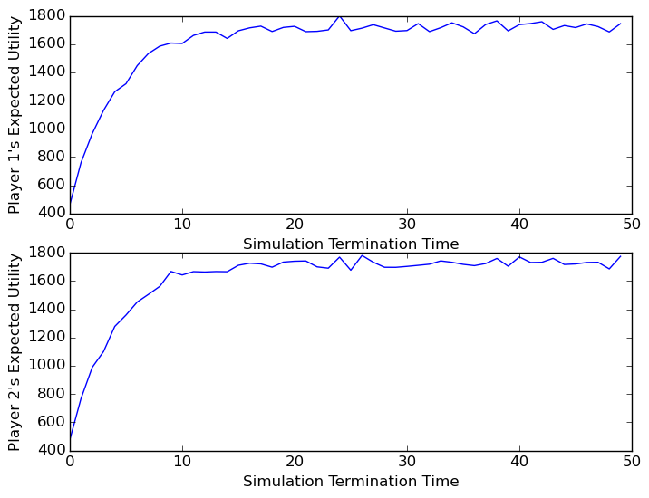

```julia
p1eu = [x[1] for x in eus];
p2eu = [x[2] for x in eus];
fig = figure("A new figure")
subplot(211)
plot(p1eu)
xlabel("Simulation Termination Time")
ylabel("Player 1's Expected Utility")
subplot(212)
plot(p2eu)
xlabel("Simulation Termination Time")
ylabel("Player 2's Expected Utility");
```

```julia
eus2 = Array[]
for i in 1000:1000:30000
    push!(eus2, compute_expected_utility(net, 20, i))
end
```

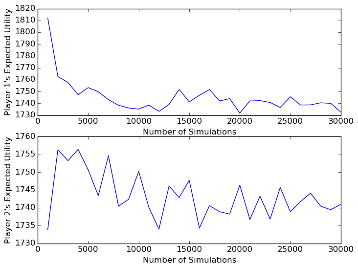

```julia
p1eu2 = [x[1] for x in eus2];
p2eu2 = [x[2] for x in eus2];
fig = figure("A new figure")
subplot(211)
plot([1000:1000:30000], p1eu2)
xlabel("Number of Simulations")
ylabel("Player 1's Expected Utility")
subplot(212)
plot( [1000:1000:30000], p2eu2)
xlabel("Number of Simulations")
ylabel("Player 2's Expected Utility");
```

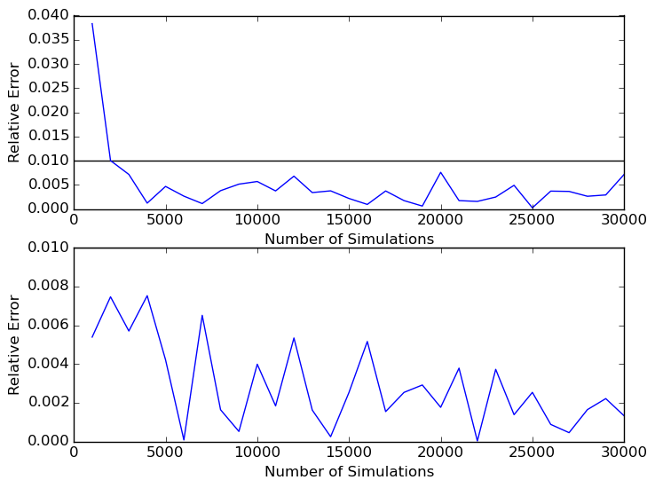

```julia
p1mean = mean(p1eu2)
p2mean = mean(p2eu2)
fig = figure("A new figure")
subplot(211)
plot([1000:1000:30000], (((p1mean-p1eu2).^2).^.5)/p1mean)
hlines(.01, 0, 30000)
xlabel("Number of Simulations")
ylabel("Relative Error")
subplot(212)
plot( [1000:1000:30000], (((p2mean-p2eu2).^2).^.5)/p2mean)
hlines(.01, 0, 30000)
xlabel("Number of Simulations")
ylabel("Relative Error");
```

The relative error in the expected utility looks reasonably low around 2000 simulations

### Distributions of Utility

```julia
params = {"mkt_to_p1" => 1.,
          "mkt_to_p2" => 1.,
          "market_state_space" => [10,20,30],
          "p1quantities" => [5,10,15,20],
          "p2quantities" => [5,10,15,20],
          "p1tomarket" => 10.,
          "p2tomarket" => 10.,
          "p1statespace" => ASCIIString["Memory1"],
          "p2statespace" => ASCIIString["Memory1"],
          "market_change_rate" => .25,
          "discount"=>.25,
          "p1c" => 1.,
          "p2c" => 1.,
          "numprofiles" => 1000,
          "numalt" => 30,
          "eunumsims" => 2000,
          "eu_tmax" =>20,
            "trembling"=> false,
          "tremble_prob"=>.1};
```

```julia
addprocs(7);
```

```julia
@everywhere require("BertrandishParallel.jl");
```

```
INFO: Loading help data...
INFO: Loading help data...
INFO: Loading help data...
INFO: Loading help data...
INFO: Loading help data...
INFO: Loading help data...
INFO: Loading help data...
INFO: Loading help data...
```

```julia
z=pmap(uniformhistogram, [params, params, params, params, params, params, params, params]);
```

```julia
function separate_parallel(parallelres)
    p1_eus = Float64[]
    p2_eus = Float64[]
    for c in parallelres
        for sim in c
            push!(p1_eus, sim[1])
            push!(p2_eus, sim[2])
        end
    end
    return p1_eus, p2_eus
end;
```

```julia
#z2 = pmap(uniformhistogram, [params, params, params, params, params, params, params, params])
```

```julia
p1_experiment1, p2_experiment1 = separate_parallel(z);
```

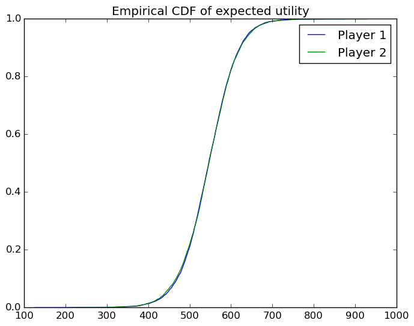

```julia
ec_p1 = ecdf(p1_experiment1)
ec_p2 = ecdf(p2_experiment1)
plot([minimum(p1_experiment1): maximum(p1_experiment1)] , ec_p1([minimum(p1_experiment1): maximum(p1_experiment1)]), label="Player 1")
plot([minimum(p2_experiment1): maximum(p2_experiment1)] , ec_p2([minimum(p2_experiment1): maximum(p2_experiment1)]), label = "Player 2")
title("Empirical CDF of expected utility")
legend();
```

This is no surprise since the parameters for player 1 and player 2 are exactly the same. The above result is more of a first-pass test to make sure the code is working as expected. We can do the same thing but this time bump up the rates of messages to and from player 1. Keep in mind, this is **not** the PGT distribution. It is just the distribution of expected utilities when we uniformly sample the joint strategy space.

# Confidence Interval Based PGT

```julia
pmap(PGT, [params, params, params, params, params, params, params, params])
```

1) Sample a joint strategy profile and compute the expected utility "almost exactly" (i.e. with a large number of runs).

2) For each alternative joint strategy profile, begin sampling the stochastic process to compute the expected utility.

3) (Suppose we are computing the intelligence for player 1's profile). After each sample of the network, compute the confidence interval of player 1's expected utility under his alternative strategy at a pre-specified significance level.

4) If the expected utility of player 1's "outerloop" strategy is outside of the confidence interval of player 1's expected utility under the alternative strategy, classify the alternative strategy as either better or worse than the outerloop strategy according to whether the outerloop strategy is above or below the confidence interval.

5) Set a predefined maximum number of simulations in case the outerloop expected utility is never outside of the confidence interval.

```julia
function is_worse(net::SFTNet, t_max::Int64, nruns::Int64, baseeu::Float64, player::Int64,
    confintmin=50, z=2.576)
    ## The player is the index to compare in the simulate output.
    runningeu = 0
    sse = 0
    s = 1
    running_sum_squares= 0
    while s < nruns
        utility = simulate(net, t_max)[player]
        e = utility - runningeu
        runningeu += e/s
        sse += e* (utility - runningeu)
        variance = sse/s
        s += 1
        if s >confintmin
            # confintmin large enough so that we can approximate the mean by a normal distribution, not t.
            conf_l = runningeu - z*(variance/s)^.5
            conf_u = runningeu + z*(variance/s)^.5
            if (baseeu < conf_l) | (baseeu>conf_u)
                s = nruns #Exit Loop
            end
        end
    end
    return runningeu
end;
```

```julia
function CI_PGT(paramdict::Any)
    mkt_to_p1 = paramdict["mkt_to_p1"]
    mkt_to_p2 = paramdict["mkt_to_p2"]
    market_state_space = paramdict["market_state_space"]
    p1quantities = paramdict["p1quantities"]
    p2quantities = paramdict["p2quantities"]
    p1tomarket = paramdict["p1tomarket"]
    p2tomarket = paramdict["p2tomarket"]
    p1statespace = paramdict["p1statespace"]
    p2statespace = paramdict["p2statespace"]
    market_change_rate = paramdict["market_change_rate"]
    discount= paramdict["discount"]
    p1c = paramdict["p1c"]
    p2c = paramdict["p2c"]
    numprofiles = paramdict["numprofiles"]
    numalt = paramdict["numalt"]
    eu_nsims = paramdict["eunumsims"]
    eu_tmax = paramdict["eu_tmax"]
    tremble = paramdict["trembling"]
    tremble_prob = paramdict["tremble_prob"]

    net = build_net_for_experiment(mkt_to_p1, mkt_to_p2, market_state_space, p1quantities, p2quantities,
                                    p1tomarket, p2tomarket, p1statespace, p2statespace, market_change_rate,
                                        discount, p1c, p2c, tremble, tremble_prob)
    messages_to_p1 = Message[]
    messages_to_p2 = Message[]
    for m in net.market.messages
        if m.receiver=="Player 1"
            push!(messages_to_p1, m)
        else
            push!(messages_to_p2, m)
        end
    end
    # Get these at the beginning so we don't have to keep searching player types
    p1possible = net.sftdict["Player 1"].messages
    p2possible = net.sftdict["Player 2"].messages
    p1statespace = net.sftdict["Player 1"].statespace
    p2statespace = net.sftdict["Player 2"].statespace
    sampled_strats = Any[]
    p1_utilities = Float64[]
    p2_utilities = Float64[]
    intels = Float64[]
    for jps in 1:numprofiles
        p1_strategy = generate_random_strategy(p1possible, messages_to_p1,
            p1statespace)
        p2_strategy = generate_random_strategy(p2possible, messages_to_p2,
            p2statespace)
        ## Need to compute twice, on for player 1 trembing and one for player 1
        push!(sampled_strats, (p1_strategy, p2_strategy))
        net.sftdict["Player 1"].strategy = p1_strategy
        net.sftdict["Player 2"].strategy = p2_strategy
        #Player 1
        net.sftdict["Player 1"].trembling=false
        net.sftdict["Player 2"].trembling=true
        eu_outer = compute_expected_utility(net, eu_tmax, eu_nsims)
        push!(p1_utilities, eu_outer[1])
        #Player 2
        net.sftdict["Player 1"].trembling=true
        net.sftdict["Player 2"].trembling=false
        eu_outer = compute_expected_utility(net, eu_tmax, eu_nsims)
        push!(p2_utilities, eu_outer[2])

        #joint_strats_eu[p1_strategy, p2_strategy] = eu_outer
        num_no_betterp1 = 0
        num_no_betterp2 = 0
        for a in 1:numalt
            net.sftdict["Player 1"].trembling=false
            net.sftdict["Player 2"].trembling=true
            p1altstrat = generate_random_strategy(p1possible, messages_to_p1,
                p1statespace)
            net.sftdict["Player 1"].strategy = p1altstrat
            eu_inner = is_worse(net, eu_tmax, eu_nsims, eu_outer[1], 1)
            if eu_inner < eu_outer[1]
                num_no_betterp1 += 1
            end
        end
        net.sftdict["Player 1"].strategy = p1_strategy
        for a in 1:numalt
            net.sftdict["Player 1"].trembling=true
            net.sftdict["Player 2"].trembling=false
            p2altstrat = generate_random_strategy(p2possible, messages_to_p2,
                p2statespace)
            net.sftdict["Player 2"].strategy = p2altstrat
            eu_inner = is_worse(net, eu_tmax, eu_nsims, eu_outer[2], 2)
            if eu_inner < eu_outer[2]
                num_no_betterp2 += 1
            end
        end
        intel = (num_no_betterp1/numalt) * (num_no_betterp2/numalt)
        push!(intels, intel)
    end
    return intels, p1_utilities, p2_utilities, sampled_strats
end;
```

```julia
function split_pgt_parallel(pgtres)
    intels = Float64[]
    p1util = Float64[]
    p2util = Float64[]
    strats = Any[]
    for core in pgtres
        for simnum in 1:length(core[1])
            if ~ (core[4][simnum] in strats)
                push!(strats, core[4][simnum])
                push!(intels, core[1][simnum])
                push!(p1util, core[2][simnum])
                push!(p2util, core[3][simnum])
            end
        end
    end
    return strats, intels, p1util, p2util
end
```

```
split_pgt_parallel (generic function with 1 method)
```

```julia
params["numprofiles"] = 1000;
```

```julia
ci_result2 = pmap(CI_PGT, [params, params, params, params, params, params, params]);
```

```julia
#splitup = split_pgt_parallel(ci_result2)
```

Using this confidence interval approach, we are indeed able to get results!

# Some result plots

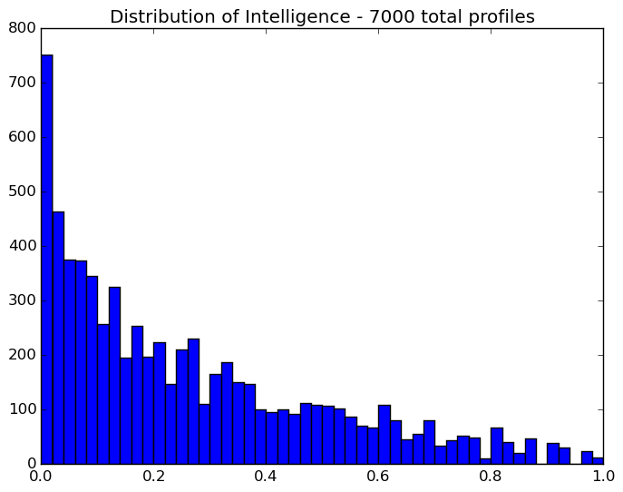

```julia
PyPlot.plt.hist(splitup[2], 50);
title("Distribution of Intelligence - 7000 total profiles");
```

```julia
using DataStructures
function plot_intelligence_cdf(intels::Array, utility::Array)
    normedprobs = intels/sum(intels)
    d=Dict{Float64, Float64}()
    # DefaultDict is not working right now.  I will just do
    # this the poor man's way
    for util_ix in 1:length(utility)
        d[utility[util_ix]] = 0
    end
    for util_ix in 1:length(utility)
        d[utility[util_ix]] += normedprobs[util_ix]
    end
    u2 = Float64[]
    p2 = Float64[]
    for (key, val) in d
        push!(u2, key)
        push!(p2, val)
    end
    std_util = sort(u2)
    std_util_ix = sortperm(u2)
    std_prob = [p2[ix] for ix in std_util_ix]
    return std_util, cumsum(std_prob)
end;
```

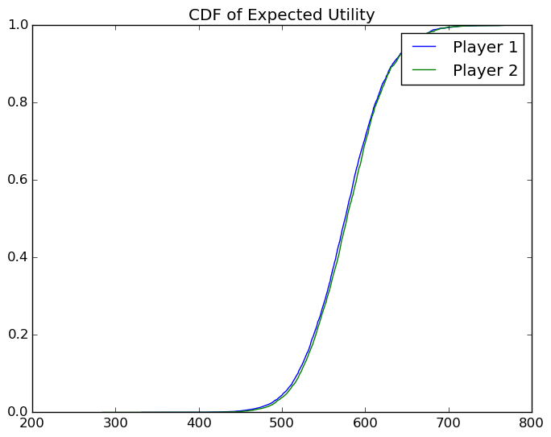

```julia
x,y= plot_intelligence_cdf(splitup[2], splitup[3]);
plot(x,y, label="Player 1");
x,y= plot_intelligence_cdf(splitup[2], splitup[4]);
plot(x,y, label="Player 2")
ylim(0,1)
title("CDF of Expected Utility")
legend();
```

This is no surprise since all of the parameters are the same for player 1 and player 2 and therefore they should have identical expected utility distributions

Let's take a look at the "convergence" of the cdf. For now, let's just do it by plotting the cdf for player 1 for different simulation lengths.

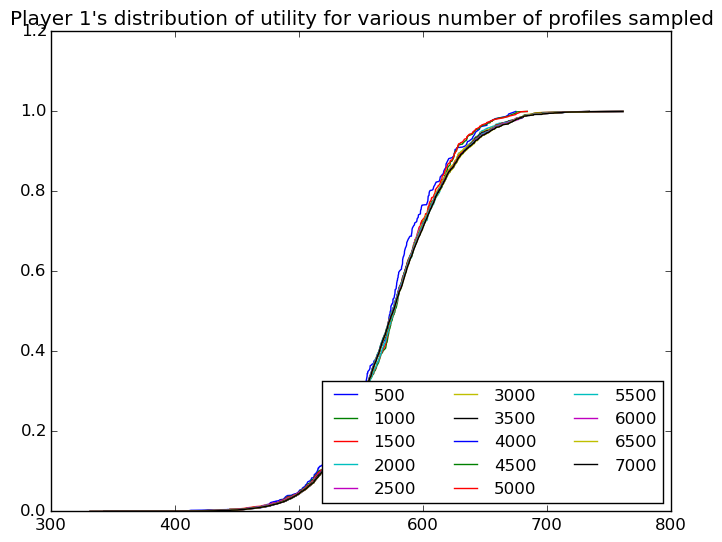

```julia
for sims in[500:500:7000]
    x,y= plot_intelligence_cdf(splitup[2][1:sims], splitup[3][1:sims]);
    plot(x,y, label=string(sims));
end
legend(ncol=3, loc=4, fontsize=12);
title("Player 1's distribution of utility for various number of profiles sampled");
```

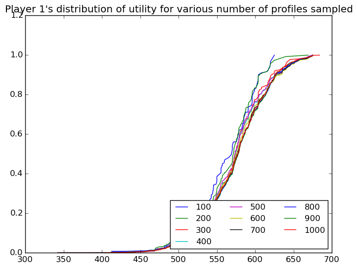

```julia
for sims in[100:100:1000]
    x,y= plot_intelligence_cdf(splitup[2][1:sims], splitup[3][1:sims]);
    plot(x,y, label=string(sims));
end
legend(ncol=3, loc=4, fontsize=12);
title("Player 1's distribution of utility for various number of profiles sampled");
```

So what is going on here? Either the simulation only requires a small number of profiles to get an accurate distribution of the distribution of utility **or** the convergence of the cdf is very slow and we are simply just not seeing it adjust with the small number of samples.

```julia
params["mkt_to_p1"]=5.
#params["p1tomarket"]= 10.
#params["numprofiles"]= 400
```

```
5.0
```

```julia
ci_result3 = pmap(CI_PGT, [params, params, params, params, params, params, params]);
```

```julia
splitup2 = split_pgt_parallel(ci_result3);
```

```julia
splitup2 = split_pgt_parallel(ci_result3);
```

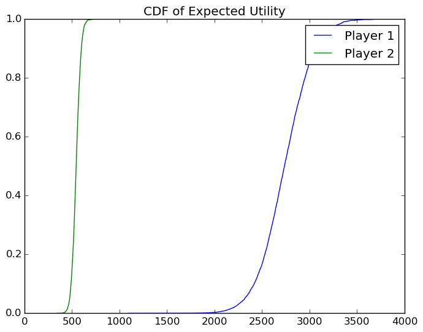

```julia
x,y= plot_intelligence_cdf(splitup2[2], splitup2[3]);
plot(x,y, label="Player 1");
x,y= plot_intelligence_cdf(splitup2[2], splitup2[4]);
plot(x,y, label="Player 2")
ylim(0,1)
title("CDF of Expected Utility")
legend();
```

This is no surprise since player one receives more orders, his profits should increase.

### Where to go

This convinces me that the code is running and doing what is expected. We also have the ability to change any parameter of the model. Now is when we need to drill down what specific types of experiments we would like to conduct...

# Scrap

- First we need to fix the player object
  - We want the player type to set a current strategy and have a container for all possible strategies
- We need a function that simulates the network up to a prespecified number of time steps where player strategies are given.
- We need a way to sample player strategies
  - Strategies are mapings from (input, state) to (output, state).
  - To get a full set of strategies, we need to know all possible messages a player can receive.
  - Need a function that takes as an input all SFTs in a game and outputs the pure strategy space for all players.
- We need a way to compute expected utility for given strategies
  - This just requires simulating a bunch of times and averaging the output
  - Produce a graph that shows the convergence of expected utility vs the number of simulation
  - Produce a graph the shows the convergence of expected utility for a given number of time steps
- Then we need a PGT algorithm
  - Once the above is implemented this should be simple:
    - Setup containers (~ 5 lines of code)
    - Sample a strategy profile for both players (two lines of code)
    - Call the EU function (1 line of code)
    - Sample alternatives for player 1 and compute EU (2 lines)
    - Sample alternatives for player 2 and compute EU (2 lines)
    - In the process, remember all EUs computed previously
- **If** we can generate a list of all proiles for each player, any records (expected utilities, intelligences and such) should be a dictionary with indices as keys. That way we save memory instead of turning an entire dictionary into a string.

```julia
i = readcsv("intel1")
p1 = readcsv("p11")
```

```
14000x1 Array{Float64,2}:
 491.4
 565.476
 206.591
 360.069
 592.697
 329.199
 224.635
 390.848
 423.369
 213.797
 539.761
 549.54
 510.72
   ⋮
 333.039
 742.592
 526.603
 359.64
 404.353
 628.549
 268.873
 391.413
 594.924
 274.436
 134.885
 290.234
```

```julia
#CI_PGT(params)
```

[output not shown]